# examples_0106

Consider the $L$-system (and angle) defined below:

- Start: `A`
- Rules:  
  `A > AXB+C+BXA`  
  `B > C--BAB--C`  
  `C > B+D-A-D+B`  
  `X > XX`  
  `D > DD`
- Number of recursions (number of iterations):
  - 5
- Angle
  - 108°

Please use [this online tool](https://draemm.li/various/fractals/l-systems/) to generate the pattern using "turtle graphics".

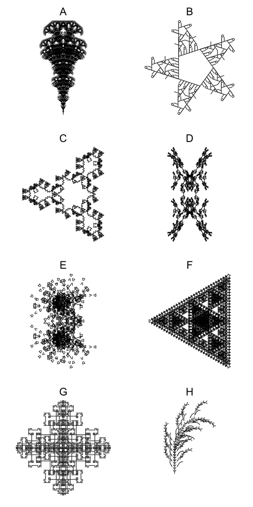

ABCDEFGH

The correct pattern is pattern E.

1. Use the first link: https://draemm.li/various/fractals/l-systems/
2. Copy/paste the `Start`, `Rules`, `Angle`, and `Recursions`.
3. I usually start `Distance` at 1. It can be less than 1, like 0.1, if needed.
4. Click `Run!`
5. If necessary to make the pattern centered and scaled, adjust the `Start pos`, `Start angle`, and `Distance`.
6. Back to the quiz, select the matching pattern.

In case you're interested in the parameters of the other patterns shown:

## Pattern A

- Start: `A`
- Rules:  
  `A > A[+A][-A]A[+B][-B]`  
  `B > A[--B][++B]B`
- Number of recursions (number of iterations):
  - 5
- Angle
  - 20

## Pattern B

- Start: `A`
- Rules:  
  `A > B+B+B+B+B`  
  `B > [-CCA]BB`  
  `C > CC`
- Number of recursions (number of iterations):
  - 5
- Angle
  - 72

## Pattern C

- Start: `CCC`
- Rules:  
  `A > C--ABA--C`  
  `B > B+C+B`  
  `C > -CA+AC-`
- Number of recursions (number of iterations):
  - 5
- Angle
  - 120

## Pattern D

- Start: `A++++++A`
- Rules:  
  `A > +B-AXBXA-B+`  
  `B > -A+BXAXB+A-`  
  `X > XX`
- Number of recursions (number of iterations):
  - 5
- Angle
  - 150

## Pattern E

- Start: `A`
- Rules:  
  `A > AXB+C+BXA`  
  `B > C--BAB--C`  
  `C > B+D-A-D+B`  
  `X > XX`  
  `D > DD`
- Number of recursions (number of iterations):
  - 5
- Angle
  - 108

## Pattern F

- Start: `AAA`
- Rules:  
  `A > A++B-C-B++A`  
  `B > B--A+C+A--B`  
  `C > CC`
- Number of recursions (number of iterations):
  - 6
- Angle
  - 60

## Pattern G

- Start: `A-A-A-A`
- Rules:  
  `A > +B-A-B+`  
  `B > -A++B+C+B++A-`  
  `C > CC`
- Number of recursions (number of iterations):
  - 6
- Angle
  - 90

## Pattern H

- Start: `A`
- Rules:  
  `A > XX[BBB+BB+B]A`  
  `X > XX`  
  `B > B[-XA][+XA]B`
- Number of recursions (number of iterations):
  - 4
- Angle
  - 30

Consider the $L$-system (and angle) defined below:

- Start: `A`
- Rules:  
  `A > ADB`  
  `B > [-CA][+CA]`  
  `C > [+C[-A][+A]][-C[-A][+A]]`  
  `D > E`  
  `E > AA`
- Number of recursions (number of iterations):
  - 7
- Angle
  - 30°

Please use [this online tool](https://draemm.li/various/fractals/l-systems/) to generate the pattern using "turtle graphics".

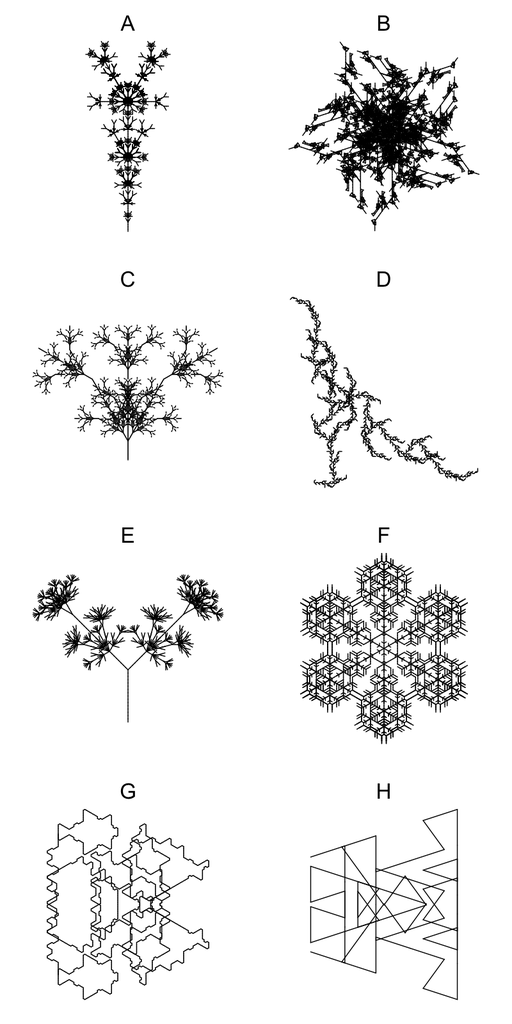

ABCDEFGH

The correct pattern is pattern A.

1. Use the first link: https://draemm.li/various/fractals/l-systems/
2. Copy/paste the `Start`, `Rules`, `Angle`, and `Recursions`.
3. I usually start `Distance` at 1. It can be less than 1, like 0.1, if needed.
4. Click `Run!`
5. If necessary to make the pattern centered and scaled, adjust the `Start pos`, `Start angle`, and `Distance`.
6. Back to the quiz, select the matching pattern.

In case you're interested in the parameters of the other patterns shown:

## Pattern A

- Start: `A`
- Rules:  
  `A > ADB`  
  `B > [-CA][+CA]`  
  `C > [+C[-A][+A]][-C[-A][+A]]`  
  `D > E`  
  `E > AA`
- Number of recursions (number of iterations):
  - 7
- Angle
  - 30

## Pattern B

- Start: `AAAAA`
- Rules:  
  `A > A+B+A`  
  `B > CC-[+CA][-CA]-B`  
  `C > CC`
- Number of recursions (number of iterations):
  - 6
- Angle
  - 108

## Pattern C

- Start: `X`
- Rules:  
  `F > FF`  
  `X > FF[+XFF+XF][-XFF-XF]FXX`
- Number of recursions (number of iterations):
  - 4
- Angle
  - 30

## Pattern D

- Start: `A++++A`
- Rules:  
  `A > +A-B-B[B]`  
  `B > -B+A+A[A]`
- Number of recursions (number of iterations):
  - 5
- Angle
  - 45

## Pattern E

- Start: `GA`
- Rules:  
  `A > [---BC][+++BC]`  
  `B > F[--AC][++AC]`  
  `C > FF[-BA][+BA]`  
  `F > FF`  
  `G > F`
- Number of recursions (number of iterations):
  - 5
- Angle
  - 15

## Pattern F

- Start: `[A]+[A]+[A]+[A]+[A]+[A]`
- Rules:  
  `A > AA[-B][+B]B`  
  `B > [-ABC][+ABC]`  
  `C > A[-CB][+CB]`
- Number of recursions (number of iterations):
  - 4
- Angle
  - 60

## Pattern G

- Start: `A`
- Rules:  
  `A > ADB+D+BDA`  
  `B > C-DAD-C`  
  `C > B+A-D-A+B`  
  `D > DD`
- Number of recursions (number of iterations):
  - 5
- Angle
  - 60

## Pattern H

- Start: `A`
- Rules:  
  `A > +B-AA-B+`  
  `B > -A+BB+A-`
- Number of recursions (number of iterations):
  - 3
- Angle
  - 108

Consider the $L$-system (and angle) defined below:

- Start: `A`
- Rules:  
  `A > A[++A][--A]A[+B][-B]`  
  `B > A[----B][++++B]B`
- Number of recursions (number of iterations):
  - 5
- Angle
  - 45°

Please use [this online tool](https://draemm.li/various/fractals/l-systems/) to generate the pattern using "turtle graphics".

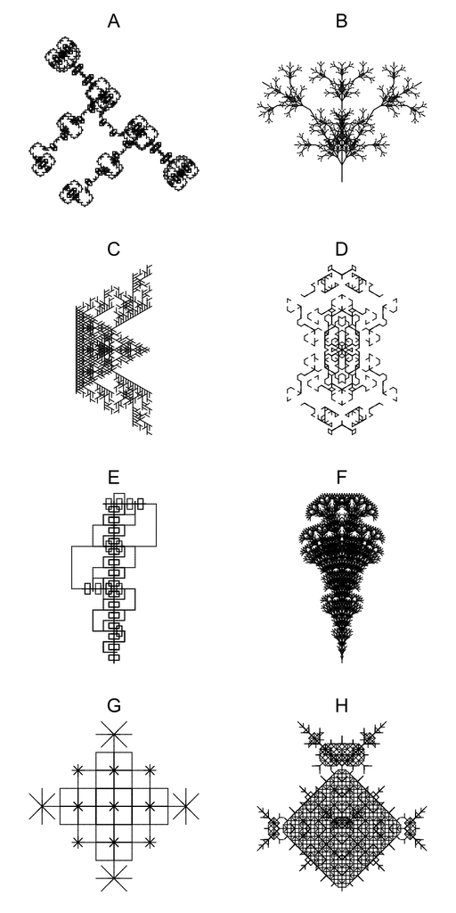

ABCDEFGH

The correct pattern is pattern H.

1. Use the first link: https://draemm.li/various/fractals/l-systems/
2. Copy/paste the `Start`, `Rules`, `Angle`, and `Recursions`.
3. I usually start `Distance` at 1. It can be less than 1, like 0.1, if needed.
4. Click `Run!`
5. If necessary to make the pattern centered and scaled, adjust the `Start pos`, `Start angle`, and `Distance`.
6. Back to the quiz, select the matching pattern.

In case you're interested in the parameters of the other patterns shown:

## Pattern A

- Start: `A`
- Rules:  
  `A > A--CBC--A`  
  `B > B+C+B`  
  `C > -CA+AC-`
- Number of recursions (number of iterations):
  - 6
- Angle
  - 90

## Pattern B

- Start: `X`
- Rules:  
  `F > FF`  
  `X > FF[+XFF+XF][-XFF-XF]FXX`
- Number of recursions (number of iterations):
  - 4
- Angle
  - 30

## Pattern C

- Start: `B---A`
- Rules:  
  `A > A[-AB]A`  
  `B > B[+BA]B`
- Number of recursions (number of iterations):
  - 5
- Angle
  - 60

## Pattern D

- Start: `AA`
- Rules:  
  `A > +B-AXB---ACA---BXA-B+`  
  `B > -A++BXA+C+AXB++A-`  
  `C > C+C`  
  `X > XXX`
- Number of recursions (number of iterations):
  - 3
- Angle
  - 60

## Pattern E

- Start: `A`
- Rules:  
  `A > B++A++A++B`  
  `B > AB[A-CC-CC-CCA]BA`  
  `C > CC`
- Number of recursions (number of iterations):
  - 5
- Angle
  - 90

## Pattern F

- Start: `A`
- Rules:  
  `A > A[+A][-A]A[+B][-B]`  
  `B > A[--B][++B]B`
- Number of recursions (number of iterations):
  - 5
- Angle
  - 20

## Pattern G

- Start: `A`
- Rules:  
  `A > [----AAB][--AAB][++AAB]AAB`  
  `B > [-C][+C][--C][++C][---C][+++C]`  
  `C > CAB`
- Number of recursions (number of iterations):
  - 3
- Angle
  - 45

## Pattern H

- Start: `A`
- Rules:  
  `A > A[++A][--A]A[+B][-B]`  
  `B > A[----B][++++B]B`
- Number of recursions (number of iterations):
  - 5
- Angle
  - 45

Consider the $L$-system (and angle) defined below:

- Start: `A++++A`
- Rules:  
  `A > [+BCC][-BCC]`  
  `B > B[-CA][+CA]`  
  `C > CCA`
- Number of recursions (number of iterations):
  - 5
- Angle
  - 45°

Please use [this online tool](https://draemm.li/various/fractals/l-systems/) to generate the pattern using "turtle graphics".

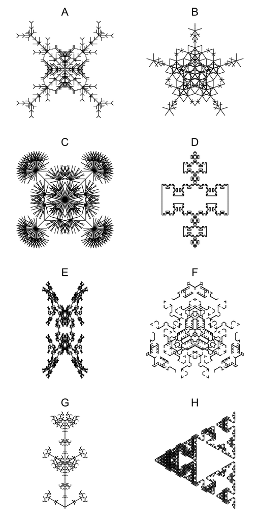

ABCDEFGH

The correct pattern is pattern A.

1. Use the first link: https://draemm.li/various/fractals/l-systems/
2. Copy/paste the `Start`, `Rules`, `Angle`, and `Recursions`.
3. I usually start `Distance` at 1. It can be less than 1, like 0.1, if needed.
4. Click `Run!`
5. If necessary to make the pattern centered and scaled, adjust the `Start pos`, `Start angle`, and `Distance`.
6. Back to the quiz, select the matching pattern.

In case you're interested in the parameters of the other patterns shown:

## Pattern A

- Start: `A++++A`
- Rules:  
  `A > [+BCC][-BCC]`  
  `B > B[-CA][+CA]`  
  `C > CCA`
- Number of recursions (number of iterations):
  - 5
- Angle
  - 45

## Pattern B

- Start: `A`
- Rules:  
  `A > [-AAB][--AAB][+AAB][++AAB]AAB`  
  `B > [-C][+C][--C][++C]CA`  
  `C > CC`
- Number of recursions (number of iterations):
  - 3
- Angle
  - 72

## Pattern C

- Start: `[A]------------[A]`
- Rules:  
  `A > [---BC][+++BC]`  
  `B > [--AC][++AC]`  
  `C > F[-BA][+BA]`  
  `F > FF`
- Number of recursions (number of iterations):
  - 5
- Angle
  - 15

## Pattern D

- Start: `-A++A`
- Rules:  
  `A > A++B-C-B++A`  
  `B > B--A+C+A--B`  
  `C > CCC`
- Number of recursions (number of iterations):
  - 5
- Angle
  - 45

## Pattern E

- Start: `A++++++A`
- Rules:  
  `A > +B-AXBXA-B+`  
  `B > -A+BXAXB+A-`  
  `X > XX`
- Number of recursions (number of iterations):
  - 5
- Angle
  - 150

## Pattern F

- Start: `A+A+A+A+A+A`
- Rules:  
  `A > +B-AXB---ACA---BXA-B+`  
  `B > -A++BXA+C+AXB++A-`  
  `C > C+C`  
  `X > XXX`
- Number of recursions (number of iterations):
  - 3
- Angle
  - 60

## Pattern G

- Start: `A.A`
- Rules:  
  `A > BC`  
  `B > B[+C][-C]`  
  `C > CAD`  
  `D > DD[+D+D][-D-D]`
- Number of recursions (number of iterations):
  - 5
- Angle
  - 60

## Pattern H

- Start: `A`
- Rules:  
  `A > B-ABA-B`  
  `B > A+B+A`
- Number of recursions (number of iterations):
  - 6
- Angle
  - 120

Consider the $L$-system (and angle) defined below:

- Start: `A`
- Rules:  
  `A > +BA+A-ABA-A+AB+`  
  `B > +BA-B--B-AB+`
- Number of recursions (number of iterations):
  - 4
- Angle
  - 90°

Please use [this online tool](https://draemm.li/various/fractals/l-systems/) to generate the pattern using "turtle graphics".

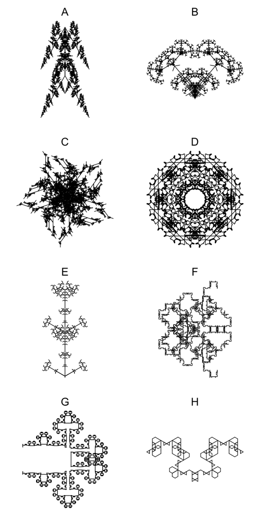

ABCDEFGH

The correct pattern is pattern F.

1. Use the first link: https://draemm.li/various/fractals/l-systems/
2. Copy/paste the `Start`, `Rules`, `Angle`, and `Recursions`.
3. I usually start `Distance` at 1. It can be less than 1, like 0.1, if needed.
4. Click `Run!`
5. If necessary to make the pattern centered and scaled, adjust the `Start pos`, `Start angle`, and `Distance`.
6. Back to the quiz, select the matching pattern.

In case you're interested in the parameters of the other patterns shown:

## Pattern A

- Start: `[+A][-B]`
- Rules:  
  `A > [-CA-CB]CA`  
  `B > [+CB+CA]CB`  
  `C > CC`
- Number of recursions (number of iterations):
  - 6
- Angle
  - 150

## Pattern B

- Start: `A`
- Rules:  
  `A > A[-DB][+DB]C`  
  `B > DC[++DA][--DA]B`  
  `C > [+++D][---D]A`  
  `D > DD`
- Number of recursions (number of iterations):
  - 6
- Angle
  - 40

## Pattern C

- Start: `AAAAA`
- Rules:  
  `A > A+B+A`  
  `B > CC-[+CA][-CA]-B`  
  `C > CC`
- Number of recursions (number of iterations):
  - 6
- Angle
  - 108

## Pattern D

- Start: `A-A-A-A-A-A-A-A`
- Rules:  
  `A > +B-CAC-B+`  
  `B > -A++BB++A-`  
  `C > CC`
- Number of recursions (number of iterations):
  - 6
- Angle
  - 45

## Pattern E

- Start: `A.A`
- Rules:  
  `A > BC`  
  `B > B[+C][-C]`  
  `C > CAD`  
  `D > DD[+D+D][-D-D]`
- Number of recursions (number of iterations):
  - 5
- Angle
  - 60

## Pattern F

- Start: `A`
- Rules:  
  `A > +BA+A-ABA-A+AB+`  
  `B > +BA-B--B-AB+`
- Number of recursions (number of iterations):
  - 4
- Angle
  - 90

## Pattern G

- Start: `A`
- Rules:  
  `A > +BA+ACCA+AB+`  
  `B > -C+++BACCAB+++C-`  
  `C > CC`
- Number of recursions (number of iterations):
  - 5
- Angle
  - 90

## Pattern H

- Start: `A`
- Rules:  
  `A > A--B--A`  
  `B > B+C+B`  
  `C > CA+AC`
- Number of recursions (number of iterations):
  - 5
- Angle
  - 60

Consider the $L$-system (and angle) defined below:

- Start: `B`
- Rules:  
  `A > [+DBC][-DBC][+++DBC]`  
  `B > [-BA][+BA]`  
  `C > AB`  
  `D > XX`  
  `X > XX`
- Number of recursions (number of iterations):
  - 6
- Angle
  - 120°

Please use [this online tool](https://draemm.li/various/fractals/l-systems/) to generate the pattern using "turtle graphics".

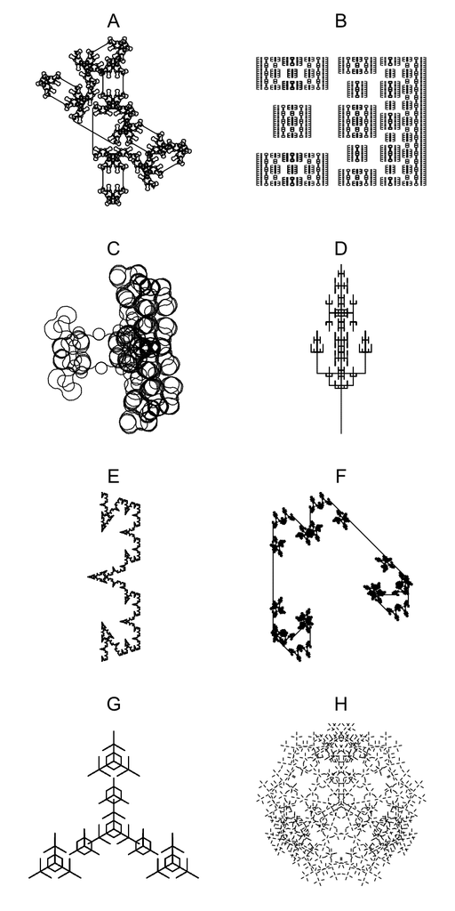

ABCDEFGH

The correct pattern is pattern G.

1. Use the first link: https://draemm.li/various/fractals/l-systems/
2. Copy/paste the `Start`, `Rules`, `Angle`, and `Recursions`.
3. I usually start `Distance` at 1. It can be less than 1, like 0.1, if needed.
4. Click `Run!`
5. If necessary to make the pattern centered and scaled, adjust the `Start pos`, `Start angle`, and `Distance`.
6. Back to the quiz, select the matching pattern.

In case you're interested in the parameters of the other patterns shown:

## Pattern A

- Start: `A`
- Rules:  
  `A > +B-ACA-ACA-B+`  
  `B > -A+BCB+BCB+A-`  
  `C > CCC`
- Number of recursions (number of iterations):
  - 5
- Angle
  - 60

## Pattern B

- Start: `A`
- Rules:  
  `A > +BX-AA-XB+`  
  `B > -AX+B+XA-`  
  `X > XX`
- Number of recursions (number of iterations):
  - 7
- Angle
  - 90

## Pattern C

- Start: `ABA`
- Rules:  
  `A > A+AA+B+AA+A`  
  `B > B-B-A-B-B`
- Number of recursions (number of iterations):
  - 4
- Angle
  - 22

## Pattern D

- Start: `A`
- Rules:  
  `A > CAA[--CAB][++CAB]`  
  `B > C[-CC-CA][+CC+CA]`  
  `C > CC`
- Number of recursions (number of iterations):
  - 5
- Angle
  - 90

## Pattern E

- Start: `A`
- Rules:  
  `A > B-ABA-B`  
  `B > A+B+A`
- Number of recursions (number of iterations):
  - 6
- Angle
  - 72

## Pattern F

- Start: `A`
- Rules:  
  `A > +B-ACA-ACA-B+`  
  `B > -A+BCB+BCB+A-`  
  `C > CCC`
- Number of recursions (number of iterations):
  - 5
- Angle
  - 135

## Pattern G

- Start: `B`
- Rules:  
  `A > [+DBC][-DBC][+++DBC]`  
  `B > [-BA][+BA]`  
  `C > AB`  
  `D > XX`  
  `X > XX`
- Number of recursions (number of iterations):
  - 6
- Angle
  - 120

## Pattern H

- Start: `[A]+++[A]+++[A]`
- Rules:  
  `A > A[---XB][-XB][+XB][+++XB]`  
  `B > XB[++XA][--XA]XA`  
  `X > XX`
- Number of recursions (number of iterations):
  - 4
- Angle
  - 40

Consider the $L$-system (and angle) defined below:

- Start: `A+++A+++A+++A`
- Rules:  
  `A > B--B`  
  `B > AA+++AA`
- Number of recursions (number of iterations):
  - 7
- Angle
  - 30°

Please use [this online tool](https://draemm.li/various/fractals/l-systems/) to generate the pattern using "turtle graphics".

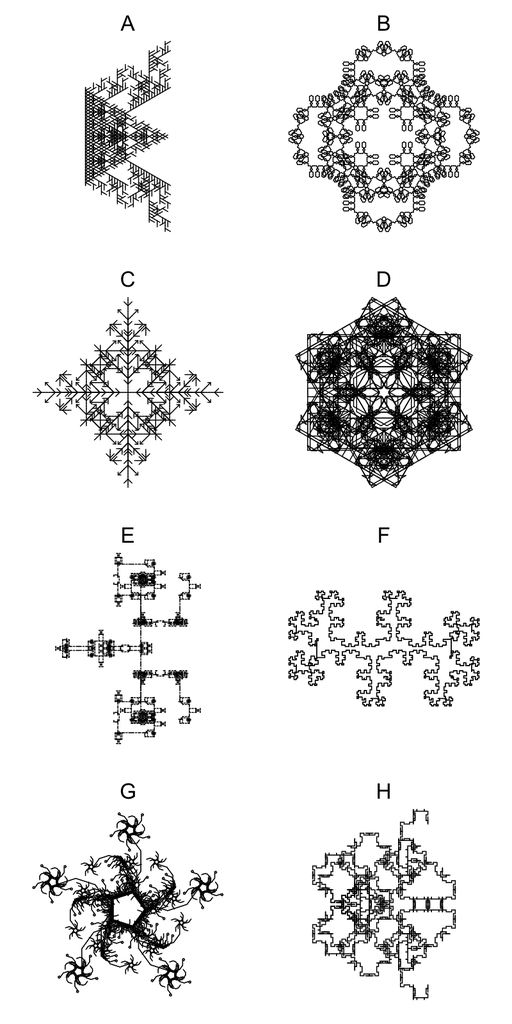

ABCDEFGH

The correct pattern is pattern B.

1. Use the first link: https://draemm.li/various/fractals/l-systems/
2. Copy/paste the `Start`, `Rules`, `Angle`, and `Recursions`.
3. I usually start `Distance` at 1. It can be less than 1, like 0.1, if needed.
4. Click `Run!`
5. If necessary to make the pattern centered and scaled, adjust the `Start pos`, `Start angle`, and `Distance`.
6. Back to the quiz, select the matching pattern.

In case you're interested in the parameters of the other patterns shown:

## Pattern A

- Start: `B---A`
- Rules:  
  `A > A[-AB]A`  
  `B > B[+BA]B`
- Number of recursions (number of iterations):
  - 5
- Angle
  - 60

## Pattern B

- Start: `A+++A+++A+++A`
- Rules:  
  `A > B--B`  
  `B > AA+++AA`
- Number of recursions (number of iterations):
  - 7
- Angle
  - 30

## Pattern C

- Start: `[A]--[A]--[A]--[A]`
- Rules:  
  `A > C[+CB][CCA][-CB]`  
  `B > CCC[+++A][---A]`  
  `C > CA`
- Number of recursions (number of iterations):
  - 4
- Angle
  - 45

## Pattern D

- Start: `AAAAAA`
- Rules:  
  `A > +BACA-A-CC-A-ACAB+`  
  `B > -AC+++BAACCCAAB+++CA-`  
  `C > CC`
- Number of recursions (number of iterations):
  - 3
- Angle
  - 150

## Pattern E

- Start: `A`
- Rules:  
  `A > +B++A-XCX-A++B+`  
  `B > -AX--BCB--XA-`  
  `C > C+AXBXA+C`  
  `X > XDX`  
  `D > DD`
- Number of recursions (number of iterations):
  - 5
- Angle
  - 90

## Pattern F

- Start: `A++A`
- Rules:  
  `A > +BA-ACA-BA+`  
  `B > -AB+CBABC+BA-`  
  `C > CCC`
- Number of recursions (number of iterations):
  - 4
- Angle
  - 90

## Pattern G

- Start: `A`
- Rules:  
  `A > B++B++B++B++B`  
  `B > B[-CCC-CC-CCA][----CC-CCB]B`  
  `C > CC`
- Number of recursions (number of iterations):
  - 5
- Angle
  - 36

## Pattern H

- Start: `A`
- Rules:  
  `A > +BA+A-ABA-A+AB+`  
  `B > +BA-B--B-AB+`
- Number of recursions (number of iterations):
  - 4
- Angle
  - 90

Consider the $L$-system (and angle) defined below:

- Start: `A`
- Rules:  
  `A > +B-AA-B+`  
  `B > -A+BB+A-`
- Number of recursions (number of iterations):
  - 3
- Angle
  - 108°

Please use [this online tool](https://draemm.li/various/fractals/l-systems/) to generate the pattern using "turtle graphics".

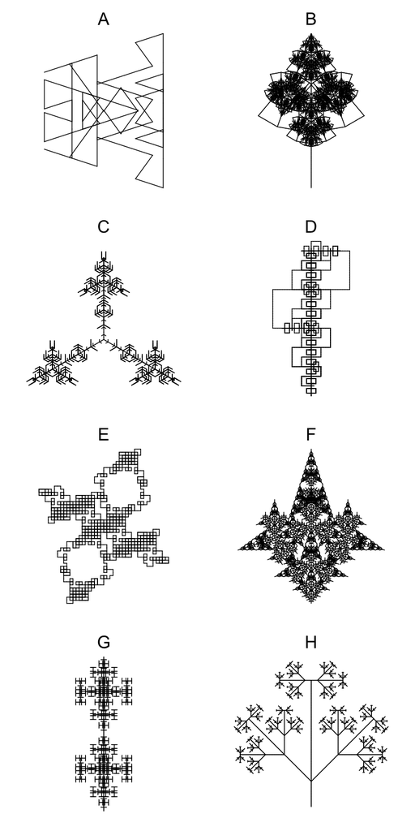

ABCDEFGH

The correct pattern is pattern A.

1. Use the first link: https://draemm.li/various/fractals/l-systems/
2. Copy/paste the `Start`, `Rules`, `Angle`, and `Recursions`.
3. I usually start `Distance` at 1. It can be less than 1, like 0.1, if needed.
4. Click `Run!`
5. If necessary to make the pattern centered and scaled, adjust the `Start pos`, `Start angle`, and `Distance`.
6. Back to the quiz, select the matching pattern.

In case you're interested in the parameters of the other patterns shown:

## Pattern A

- Start: `A`
- Rules:  
  `A > +B-AA-B+`  
  `B > -A+BB+A-`
- Number of recursions (number of iterations):
  - 3
- Angle
  - 108

## Pattern B

- Start: `A`
- Rules:  
  `A > CAA[--CAB][++CAB]`  
  `B > C[-CC-CA][+CC+CA]`  
  `C > CC`
- Number of recursions (number of iterations):
  - 5
- Angle
  - 100

## Pattern C

- Start: `[A]+[A]+[A]`
- Rules:  
  `A > AA[-B][+B]B`  
  `B > [-ABC][+ABC]`  
  `C > A[-CB][+CB]`
- Number of recursions (number of iterations):
  - 4
- Angle
  - 120

## Pattern D

- Start: `A`
- Rules:  
  `A > B++A++A++B`  
  `B > AB[A-CC-CC-CCA]BA`  
  `C > CC`
- Number of recursions (number of iterations):
  - 5
- Angle
  - 90

## Pattern E

- Start: `AA`
- Rules:  
  `A > B-AA-B`  
  `B > AB+B+A`
- Number of recursions (number of iterations):
  - 5
- Angle
  - 90

## Pattern F

- Start: `A`
- Rules:  
  `A > A[+A][-A]B`  
  `B > A[--B][++B]B`
- Number of recursions (number of iterations):
  - 6
- Angle
  - 108

## Pattern G

- Start: `AA`
- Rules:  
  `A > ABA`  
  `B > C[-BAB][+BAB]`  
  `C > CC`
- Number of recursions (number of iterations):
  - 5
- Angle
  - 90

## Pattern H

- Start: `A`
- Rules:  
  `A > C[+CA][CCCCB][-CA]`  
  `B > [++A][--A]`  
  `C > CC`
- Number of recursions (number of iterations):
  - 6
- Angle
  - 45

Consider the $L$-system (and angle) defined below:

- Start: `A`
- Rules:  
  `A > ABA`  
  `B > [-BAB][+BAB]`
- Number of recursions (number of iterations):
  - 6
- Angle
  - 90°

Please use [this online tool](https://draemm.li/various/fractals/l-systems/) to generate the pattern using "turtle graphics".

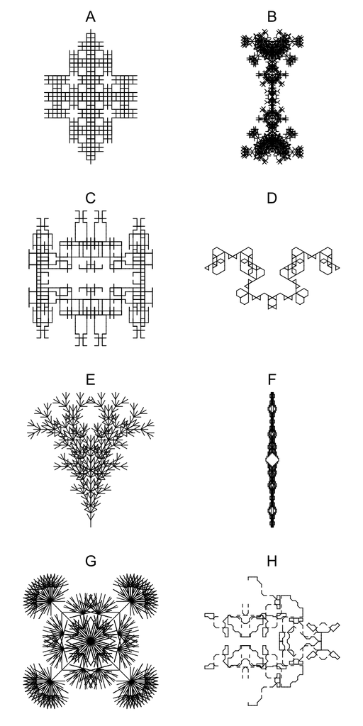

ABCDEFGH

The correct pattern is pattern A.

1. Use the first link: https://draemm.li/various/fractals/l-systems/
2. Copy/paste the `Start`, `Rules`, `Angle`, and `Recursions`.
3. I usually start `Distance` at 1. It can be less than 1, like 0.1, if needed.
4. Click `Run!`
5. If necessary to make the pattern centered and scaled, adjust the `Start pos`, `Start angle`, and `Distance`.
6. Back to the quiz, select the matching pattern.

In case you're interested in the parameters of the other patterns shown:

## Pattern A

- Start: `A`
- Rules:  
  `A > ABA`  
  `B > [-BAB][+BAB]`
- Number of recursions (number of iterations):
  - 6
- Angle
  - 90

## Pattern B

- Start: `A++++XA`
- Rules:  
  `A > AA[-B][+B]B`  
  `B > [---ABC][+++ABC]`  
  `C > A[-CB][+CB]`  
  `X > XX`
- Number of recursions (number of iterations):
  - 5
- Angle
  - 45

## Pattern C

- Start: `B--B`
- Rules:  
  `A > +B++A-DCD-A++B+`  
  `B > -AD--BCB--DA-`  
  `C > C+ADBDA+C`  
  `D > DD`
- Number of recursions (number of iterations):
  - 4
- Angle
  - 90

## Pattern D

- Start: `A`
- Rules:  
  `A > A--B--A`  
  `B > B+C+B`  
  `C > CA+AC`
- Number of recursions (number of iterations):
  - 5
- Angle
  - 60

## Pattern E

- Start: `A`
- Rules:  
  `A > A[+A][-A]B`  
  `B > [--B][++B]A`
- Number of recursions (number of iterations):
  - 5
- Angle
  - 30

## Pattern F

- Start: `A--A`
- Rules:  
  `A > +B-CAC-B+`  
  `B > -A+B+A-`  
  `C > CC`
- Number of recursions (number of iterations):
  - 6
- Angle
  - 90

## Pattern G

- Start: `[A]------------[A]`
- Rules:  
  `A > [---BC][+++BC]`  
  `B > [--AC][++AC]`  
  `C > F[-BA][+BA]`  
  `F > FF`
- Number of recursions (number of iterations):
  - 5
- Angle
  - 15

## Pattern H

- Start: `A`
- Rules:  
  `A > AXB+C+BXA`  
  `B > C--BAB--C`  
  `C > B+D-A-D+B`  
  `X > XX`  
  `D > DD`
- Number of recursions (number of iterations):
  - 4
- Angle
  - 45

Consider the $L$-system (and angle) defined below:

- Start: `B---A`
- Rules:  
  `A > A[-AB]A`  
  `B > B[+BA]B`
- Number of recursions (number of iterations):
  - 5
- Angle
  - 60°

Please use [this online tool](https://draemm.li/various/fractals/l-systems/) to generate the pattern using "turtle graphics".

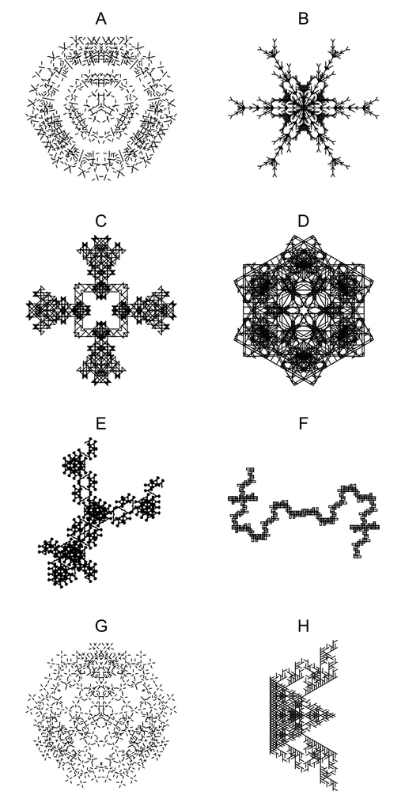

ABCDEFGH

The correct pattern is pattern H.

1. Use the first link: https://draemm.li/various/fractals/l-systems/
2. Copy/paste the `Start`, `Rules`, `Angle`, and `Recursions`.
3. I usually start `Distance` at 1. It can be less than 1, like 0.1, if needed.
4. Click `Run!`
5. If necessary to make the pattern centered and scaled, adjust the `Start pos`, `Start angle`, and `Distance`.
6. Back to the quiz, select the matching pattern.

In case you're interested in the parameters of the other patterns shown:

## Pattern A

- Start: `[A]+++[A]+++[A]`
- Rules:  
  `A > A[---XB][-XB][+XB][+++XB]`  
  `B > XB[++XA][--XA]A`  
  `X > XX`
- Number of recursions (number of iterations):
  - 4
- Angle
  - 40

## Pattern B

- Start: `A++++A++++A`
- Rules:  
  `A > [+BCC][-BCC]`  
  `B > B[-CA][+CA]`  
  `C > CCA`
- Number of recursions (number of iterations):
  - 5
- Angle
  - 30

## Pattern C

- Start: `A++A++A++A`
- Rules:  
  `A > B-ABA-B`  
  `B > A+BB+A`
- Number of recursions (number of iterations):
  - 4
- Angle
  - 135

## Pattern D

- Start: `AAAAAA`
- Rules:  
  `A > +BACA-A-CC-A-ACAB+`  
  `B > -AC+++BAACCCAAB+++CA-`  
  `C > CC`
- Number of recursions (number of iterations):
  - 3
- Angle
  - 150

## Pattern E

- Start: `A`
- Rules:  
  `A > +BA-A--B--A-AB+`  
  `B > -AB+B++A++B+BA-`
- Number of recursions (number of iterations):
  - 5
- Angle
  - 60

## Pattern F

- Start: `AA`
- Rules:  
  `A > B-AA-B`  
  `B > AB+B+AB`
- Number of recursions (number of iterations):
  - 5
- Angle
  - 90

## Pattern G

- Start: `[A]+++[A]+++[A]`
- Rules:  
  `A > A[---XB][-XB][+XB][+++XB]`  
  `B > XB[++XA][--XA]XA`  
  `X > XX`
- Number of recursions (number of iterations):
  - 4
- Angle
  - 40

## Pattern H

- Start: `B---A`
- Rules:  
  `A > A[-AB]A`  
  `B > B[+BA]B`
- Number of recursions (number of iterations):
  - 5
- Angle
  - 60